# Week 5: Centrality

## Introduction to Centrality

Background: At the individual level, one dimension of position in the network can be captured through centrality.

Conceptually, centrality is fairly straight forward: we want to identify which nodes are in the ‘center’ of the network. In practice, identifying exactly what we mean by ‘center’ is somewhat complicated.

Node Leve Measures: Degree, Closeness, Betweenness, Power

Graph Level measures: Centralization

## Digging into Groups: Florentine Marriage Network

Let’s get a quick look at our exemplar data sets. Second: the Florentine Marriage Network. Here, the nodes are families and the edges are marital ties. Florence around 1430 was experiencing rapid economic and political transformation and we see two points of struggle between the Medicis and the Strozzis.

## Digging into Centrality: Florentine Marriage Network

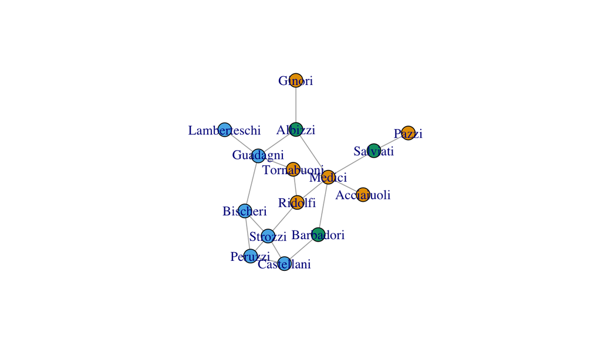

## What is an important actor?

Intuitively, we want a method that allows us to distinguish “important” actors. Consider the following graphs:

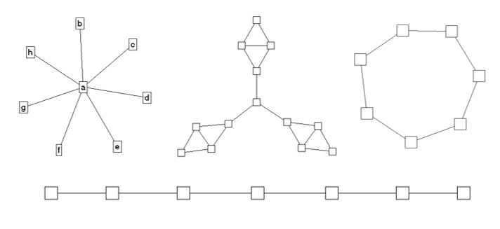

## Important actors are most connected (degree)

The most intuitive notion of centrality focuses on degree: The actor with the most ties is the most important:

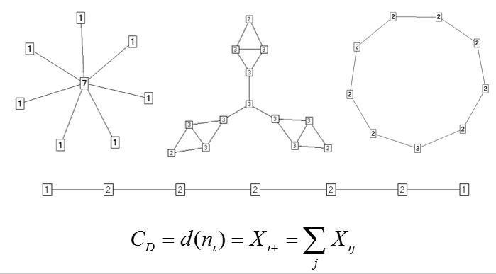

## Degree in R

So our old friend degree is back!

degree centrality <- degree(g)

## Degree in R

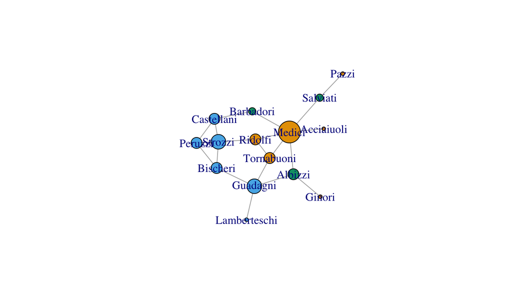

## Degree is a local measure

Degree centrality, however, can be deceiving, because it is a purely local measure.

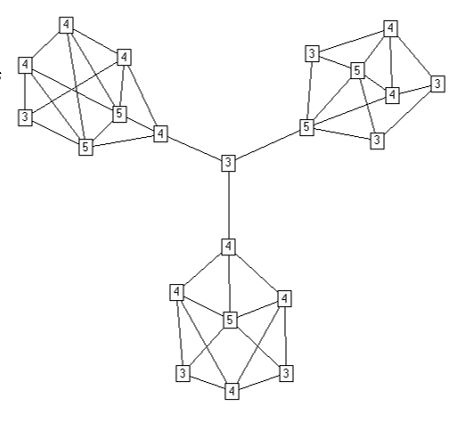

## Degree as a graph property

To understand degree as a graph property, we can use variance or we can use Freeman’s general formula for centralization:

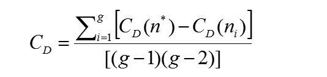

## Degree Centralization and Variance

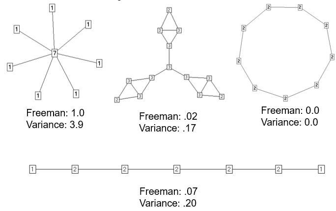

## Closeness Centrality

A second measure of centrality is closeness centrality. An actor is considered important if he/she is relatively close to all other actors.

Closeness is based on the inverse of the distance of each actor to every other actor in the network.

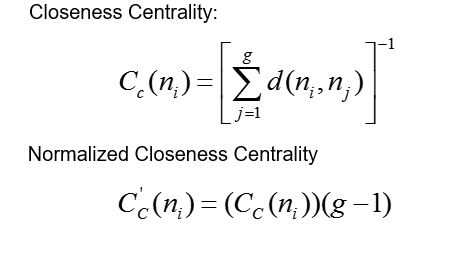

## Closeness Centrality in R

close_centrality <- closeness(g)

centralization.closeness(g)

```
## [1] 0.3224523
```

## Closeness Centrality

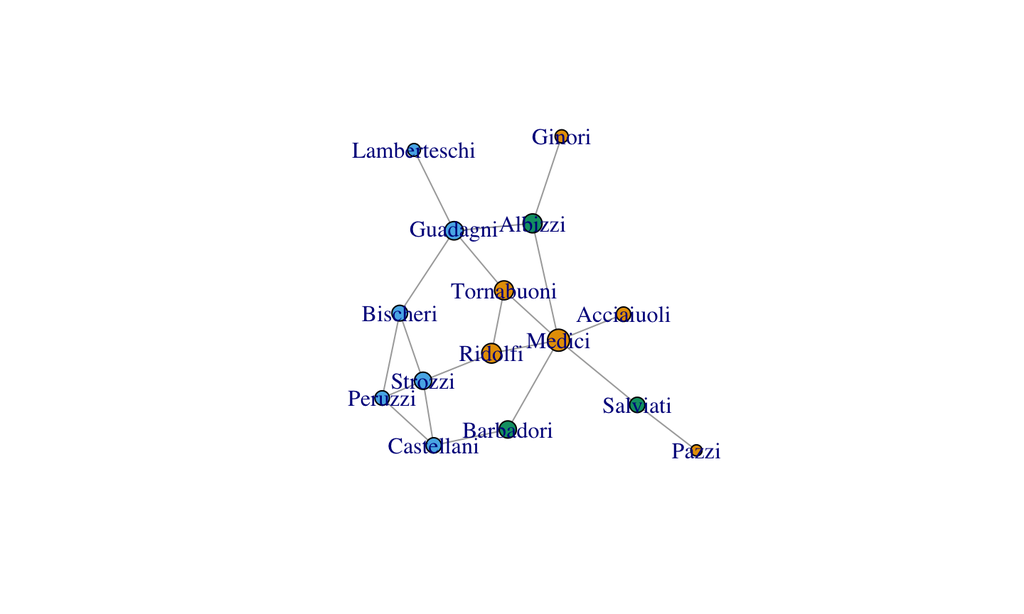

## Betweenness Centrality

Model based on communication flow: A person who lies on communication paths can control communication flow, and is thus important. Betweenness centrality counts the number of shortest paths between i and k that actor j resides on.

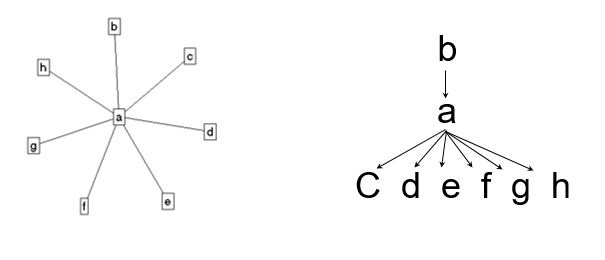

## Betweenness Centrality

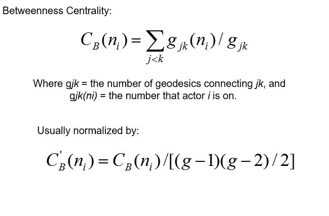

## Betweenness Centrality

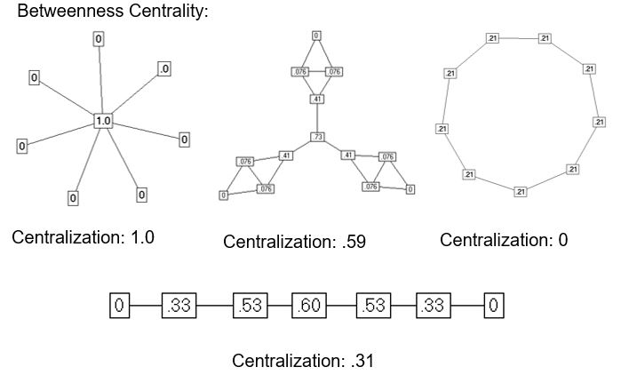

## Betweenness Centrality in R

between_centrality <- betweenness(g)

## Betweenness Centrality in R

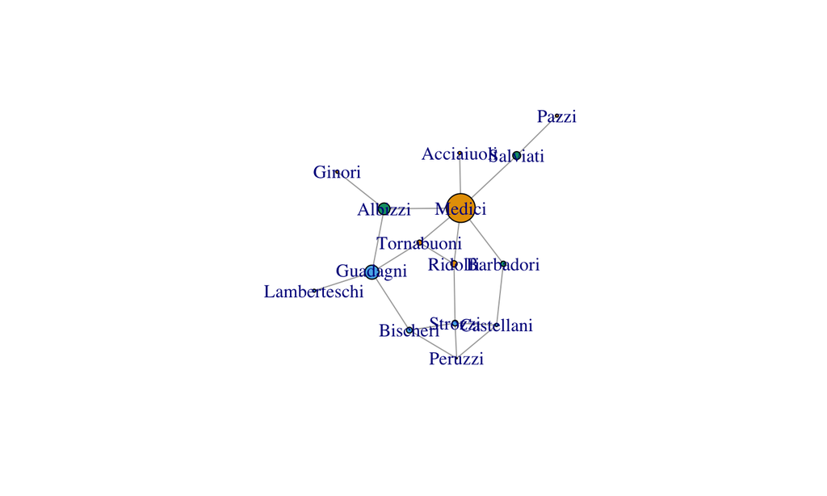

## Comparing Degree, Closeness, and Betweenness

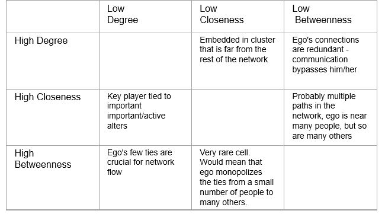

## Power and Influence Centrality

Bonacich Power Centrality: Actor’s centrality (prestige) is equal to a function of the prestige of those they are connected to. Thus, actors who are tied to very central actors should have higher prestige/ centrality than those who are not.

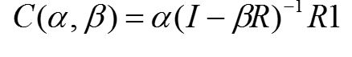

- a is a scaling vector, which is set to normalize the score.  
- b reflects the extent to which you weight the - centrality of people ego is tied to. -R is the adjacency matrix (can be valued) -I is the identity matrix (1s down the diagonal) -1 is a matrix of all ones.

## Power and Influence Centrality

The magnitude of b reflects the radius of power. Small values of b weight local structure, larger values weight global structure.

If b is positive, then ego has higher centrality when tied to people who are central.

If b is negative, then ego has higher centrality when tied to people who are not central.

As b approaches zero, you get degree centrality.

## Power and Influence Centrality

Eigenvector centrality is often conceptualized as a capturing infleunce. Eigenvector centrality is a relative measure where connections to high-scoring nodes are more highly weighted. PageRank is a version of eigenvector centrality.

## Power Centrality in R

Node-level power centrality: power_centrality(g)

Graph-level power centralization is not implemented in igraph.

Node-level eigenvector centrality: eigen_centrality(g)

Graph-level eigenvector centrality: centr_eigen(g)

```
## [1] 0.5277086
```

## Power Centrality in R

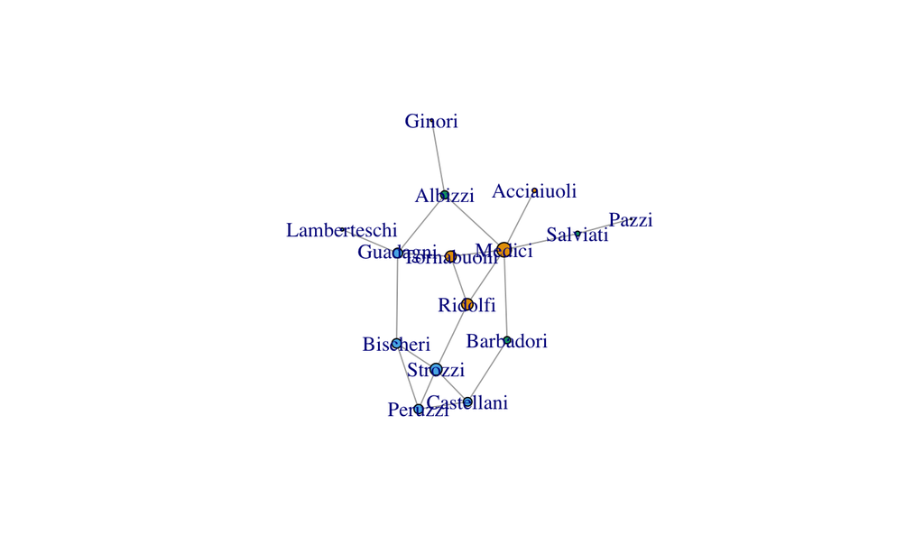

## Working with Centrality

In recent work, Borgatti (2003; 2005) discusses centrality in terms of two key dimensions:

Substantively, the key question for centrality is knowing what is flowing through the network. The key features are: Radial: Whether the actor retains the good to pass to others (Information, Diseases) or medial: whether they pass the good and then lose it (physical objects)

Whether the key factor for spread is distance (disease with low pij) or multiple sources (information)

The off-the-shelf measures do not always match the social process of interest, so researchers need to be mindful of this.

## Working with Centrality

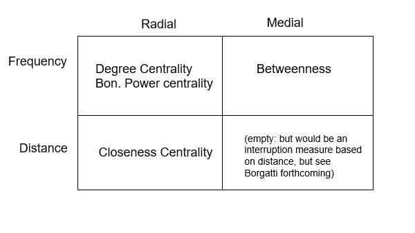

## Betweenness by Constraint

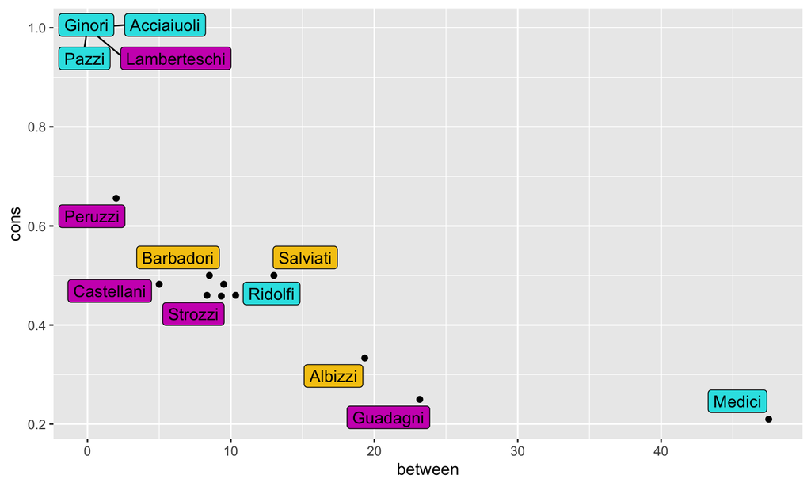

## Degree by Constraint

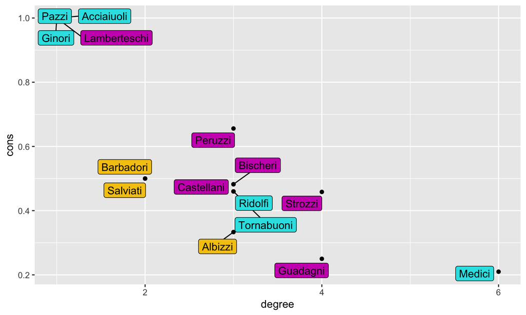